# Graphiques avec ggplot2

Mardi 25 mai 2021

## Avant toutes choses

Nous aurons besoin du package `ggplot2` :

- Vérifier que le package `ggplot2` est bien installé
- Si non, l’installer, puis le charger

```r
library(ggplot2)
```

Nous allons également avoir besoin des données fruits :

```r
data("fruits", package = "tidyViz")
```

## Bien choisir sa représentation graphique

[figure not shown]

From Data to Viz : https://www.data-to-viz.com/

## Un échantillon de ce qu’il est possible de faire avec ggplot2

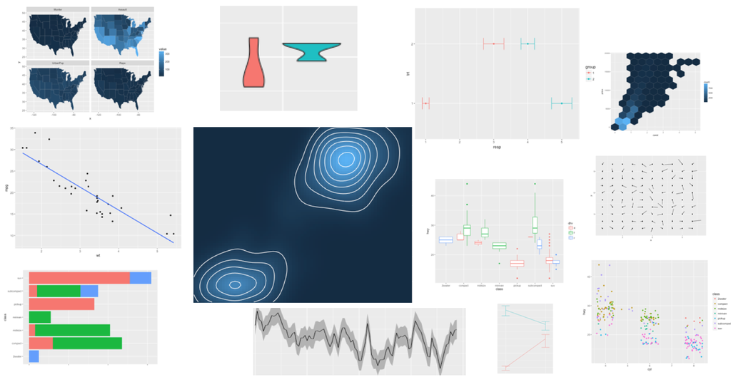

## Diagramme en bâtons

## Rappel : la fonction barplot

La fonction de base pour les diagrammes en bâtons est `barplot` :

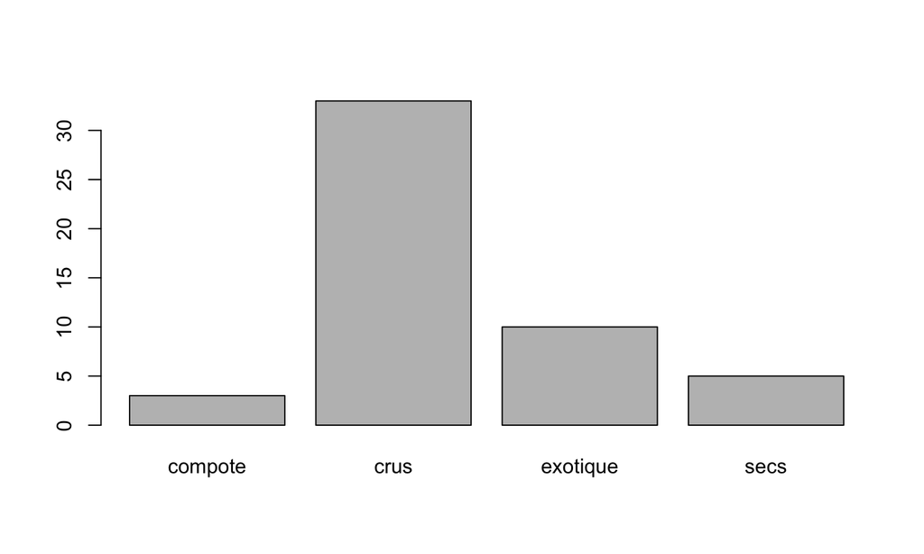

```r
barplot(table(fruits$groupe))
```

Avec des couleurs :

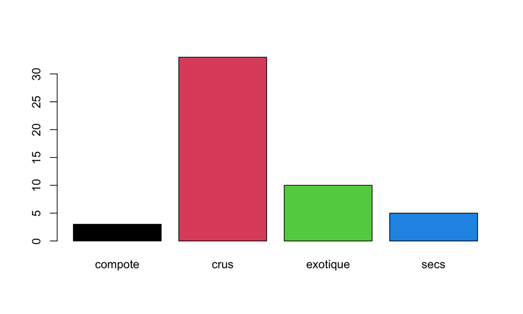

```r
barplot(table(fruits$groupe), col = 1:4)
```

## La fonction geom_bar

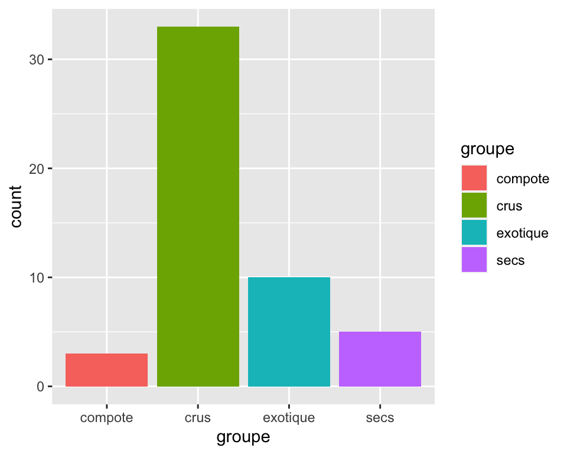

```r
ggplot(data = fruits, aes(x = groupe, fill = groupe)) +
  geom_bar()
```

STOP !

## Décomposition de la commande

- `ggplot` : création d’un canevas vide dans on va dessiner le(s) graphe(s)
- `aes` : déclaration des paramètres esthétiques du graphes (position horizontale, verticale, couleur épaisseur, forme, transparence etc…)
- `geom_bar` : utilisation d’une géométrie

## Les données

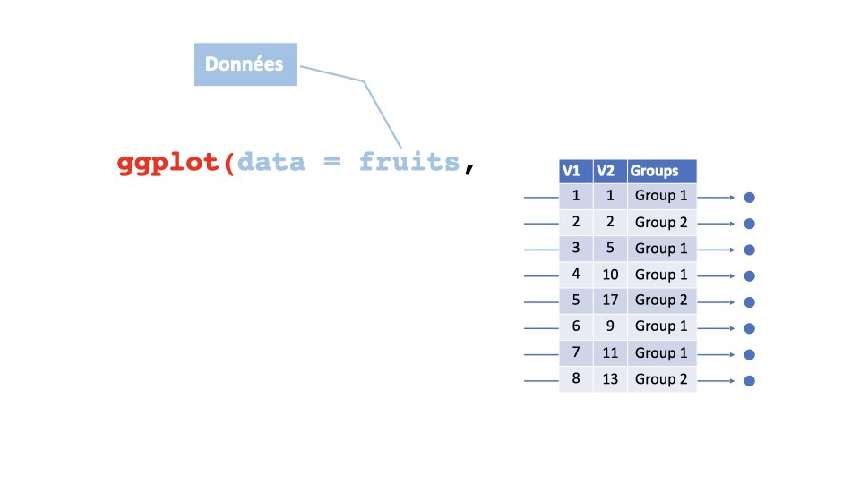

## Les paramètres esthétiques

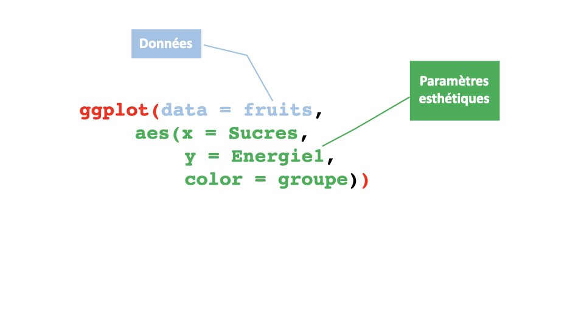

## Les géométries

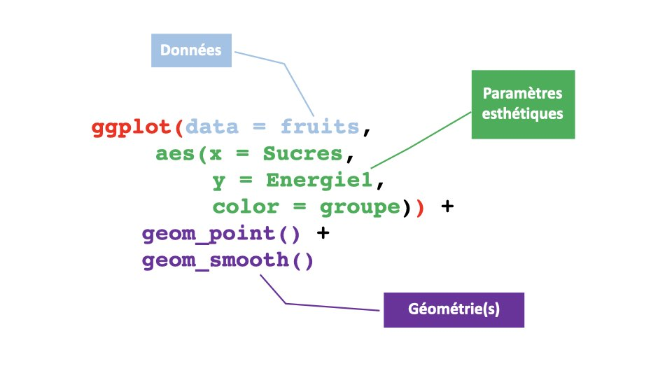

## L’image à retenir

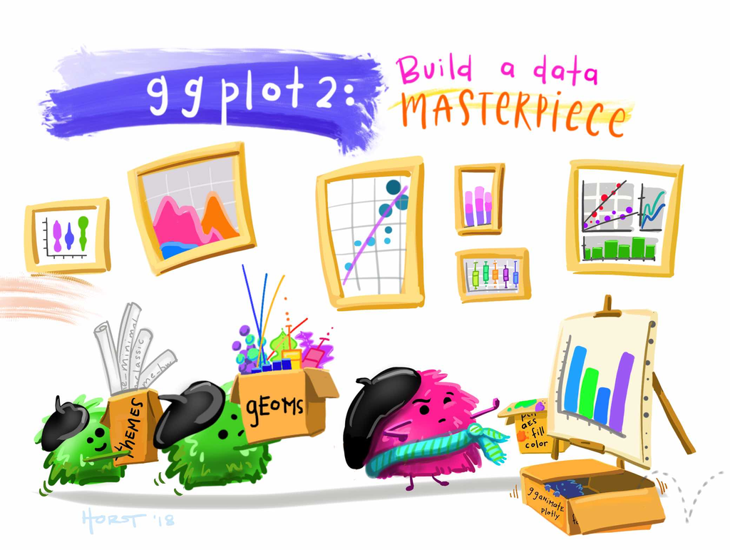

## [G]rammar of [G]raphics

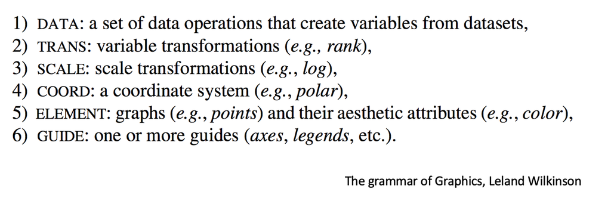

## Implémentation dans ggplot2

[output not shown]

## A vous !

Comment corriger la commande suivante pour obtenir le graphe à droite ?

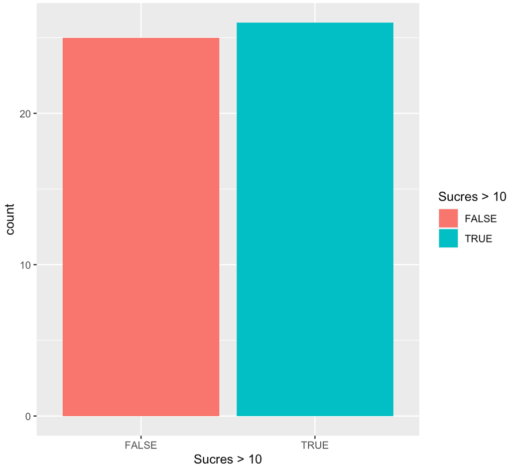

```r
 ggplot(***,
     aes(***,
     fill = Sucres > 10)) +
   geom_***()
```

## Un peu d’histoire

- Il y a eu un `ggplot`“1” (voir [ici](https://github.com/hadley/ggplot1))
- Développement commencé en 2005
- Hadley Wickham (*Chief Scientist at RStudio* + *Adjunct Professor of Statistics*)
- D’excellents cours, parfois avec sa soeur Charlotte

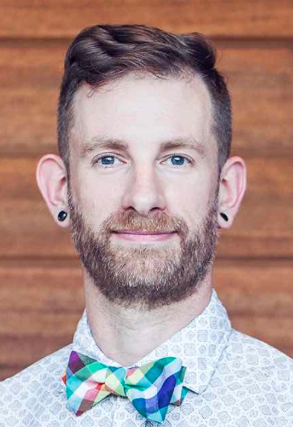

Hadley Wickham

## Quelques géométries

Nous allons voir ensemble quelques géométries particulières qui permettent de créer des graphes classiques.

| `geom_bar` | Diagramme en bâtons sur des données non-agrégées |
| --- | --- |
| `geom_col` | Diagramme en bâtons (encore) sur des comptages existants |
| `geom_histogram` | Histogramme d’une variable quantitative |
| `geom_boxplot` | Diagramme de Tukey aka “boîte à moustache” aka *boxplot* |
| `geom_violin` | Diagramme en “violons” |
| `geom_point` | Nuage de points créé à partir de deux variables quantitatives |
| `geom_line` | Ligne tracée à partir de deux variables quantitatives |

## Diagrammes en bâtons

## Avec geom_bar

On a déjà vu comment faire :

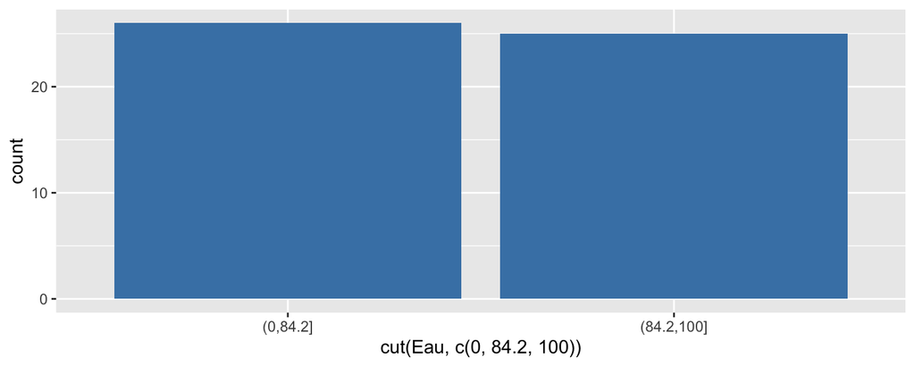

```r
ggplot(fruits, aes(cut(Eau, c(0, 84.2, 100)))) +
  geom_bar(fill = "steelblue")
```

## Avec geom_col

S’utilise **quand on dispose déjà** de comptages.

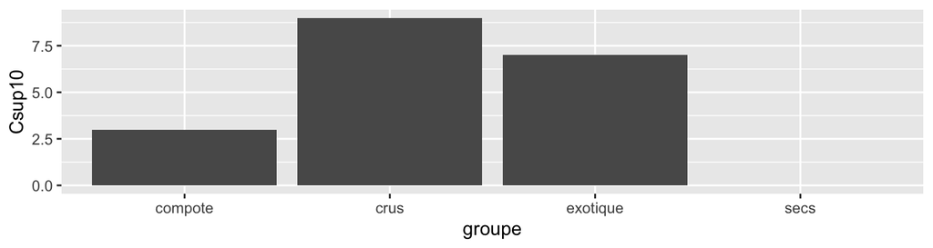

```r
dat.count <- fruits %>%
  group_by(groupe) %>%
  summarize(Csup10 = sum(VitamineC >= 10))

ggplot(data = dat.count, aes(x = groupe, y = Csup10)) +
  geom_col()
```

## A vous !

Comment modifier les deux commandes précédentes pour faire un diagramme en bâtons montrant des pourcentages plutôt que des comptages bruts ?

(PS : il y a plus d’une solution possible)

## Histogrammes

## Histogramme ou diagramme en bâtons ?

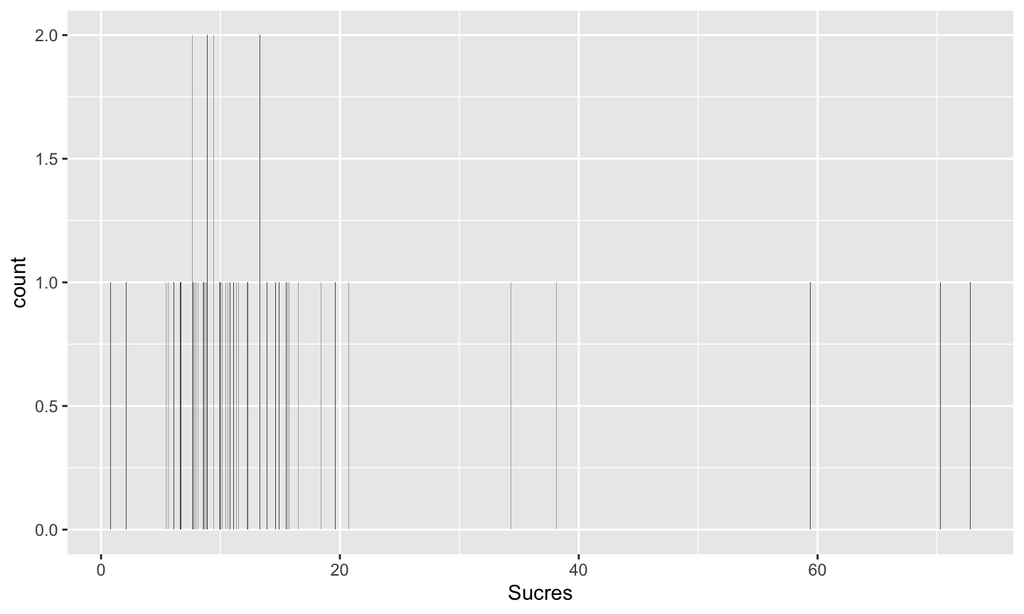

```r
ggplot(fruits, aes(Sucres)) +
  geom_bar()
```

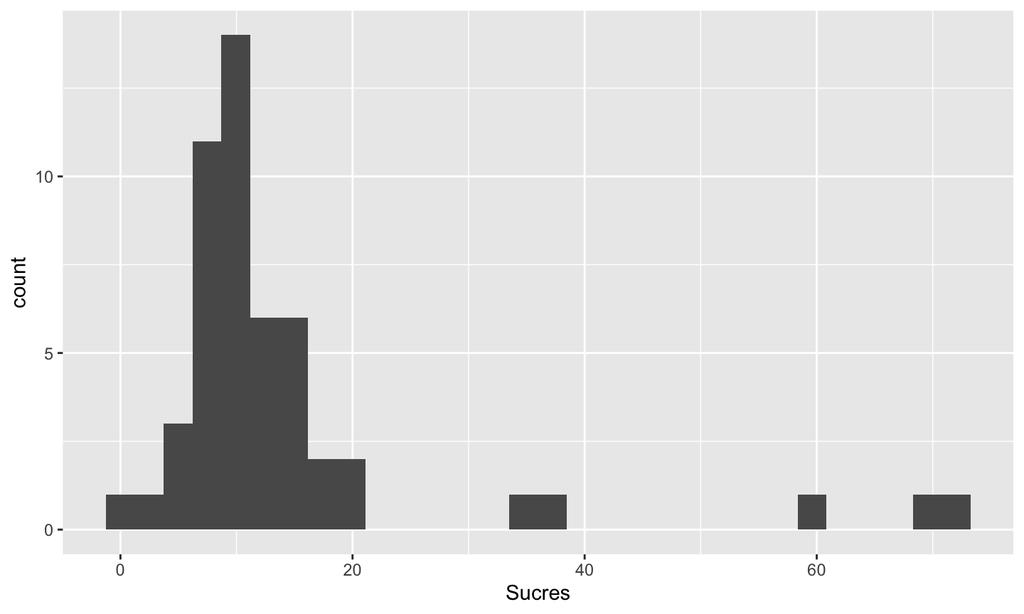

```r
ggplot(fruits, aes(Sucres)) +
  geom_histogram()
```

## Histogramme ou diagramme en bâtons ?

### Diagramme en bâtons

Représente des comptages de :

- variables nominales
- variables ordinales
- variables discrètes

### Histogramme

Représente des comptages ou des densités de :

- variables continues
- variables discrètes

Pour ce genre de graphe, il est important de choisir les intervalles sur lesquels les données seront énumérées.

## L’histogramme par défaut

- Axe des \(y\) : les comptages de l’intervalle donné
- Axe des \(x\) :
  - des intervalles de même amplitude,
  - trente intervalles,
  - pas de séparation visuelle entre les intervalles (sauf ceux qui sont vides)
  - des *rectangles* gris foncé
  - un *message*

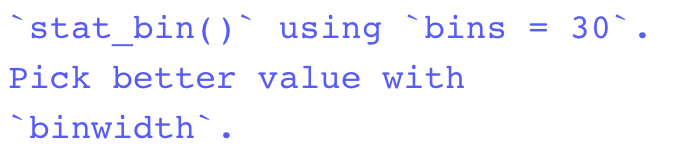

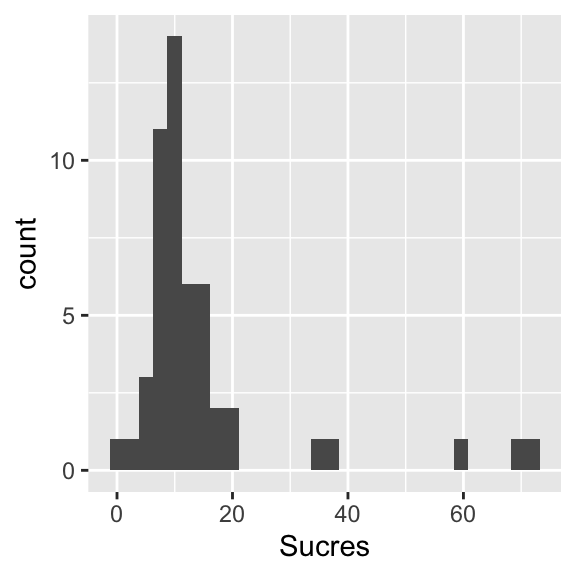

```r
ggplot(fruits, aes(Sucres)) +
  geom_histogram()
```

## Exercice qui n’a (presque) rien à voir!

Dans un document R Markdown, comment faire pour ne pas afficher le message dans votre rapport ?

*… il y a plusieurs solutions possibles…*

## Modification des intervalles

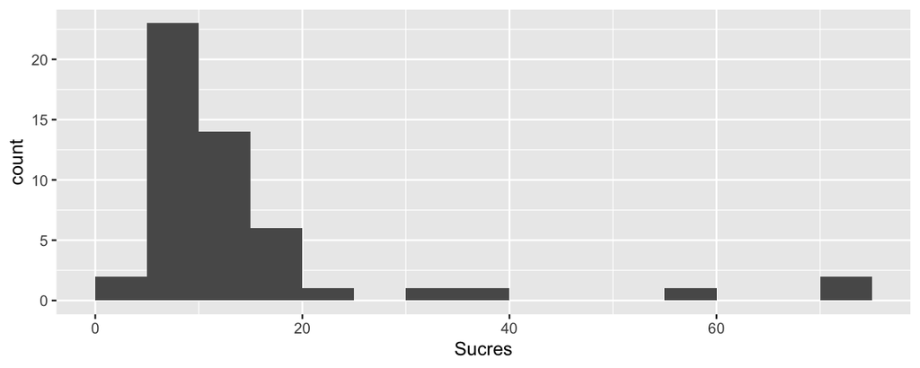

```r
ggplot(fruits, aes(Sucres)) +
  geom_histogram(breaks = seq(0, 75, 5))
```

## Modification de la couleur

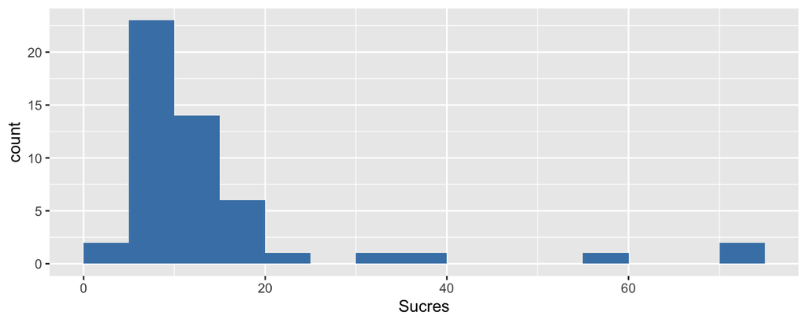

```r
ggplot(fruits, aes(Sucres)) +
  geom_histogram(breaks = seq(0, 75, 5),
                 fill = "steelblue")
```

## Modification de la couleur

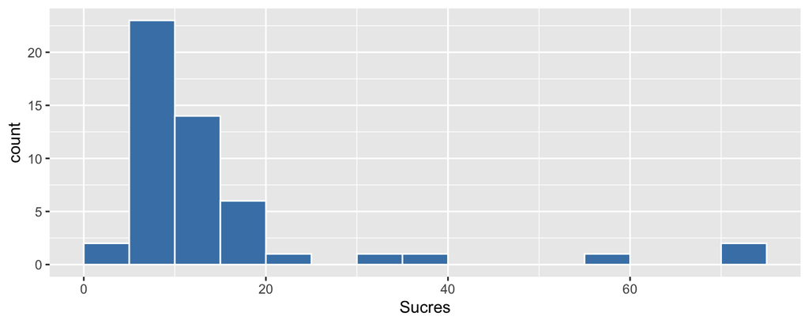

```r
ggplot(fruits, aes(Sucres)) +
  geom_histogram(breaks = seq(0, 75, 5),
                 fill = "steelblue",
                 color = "white")
```

## Boxplot

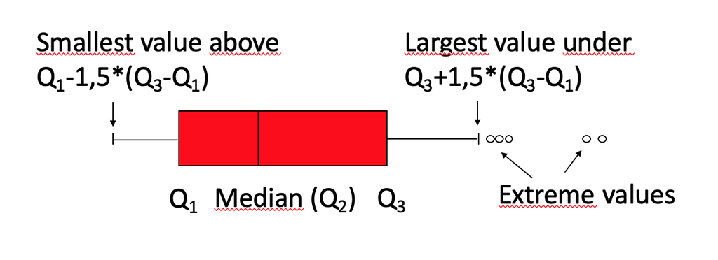

## Boxplot d’une variable

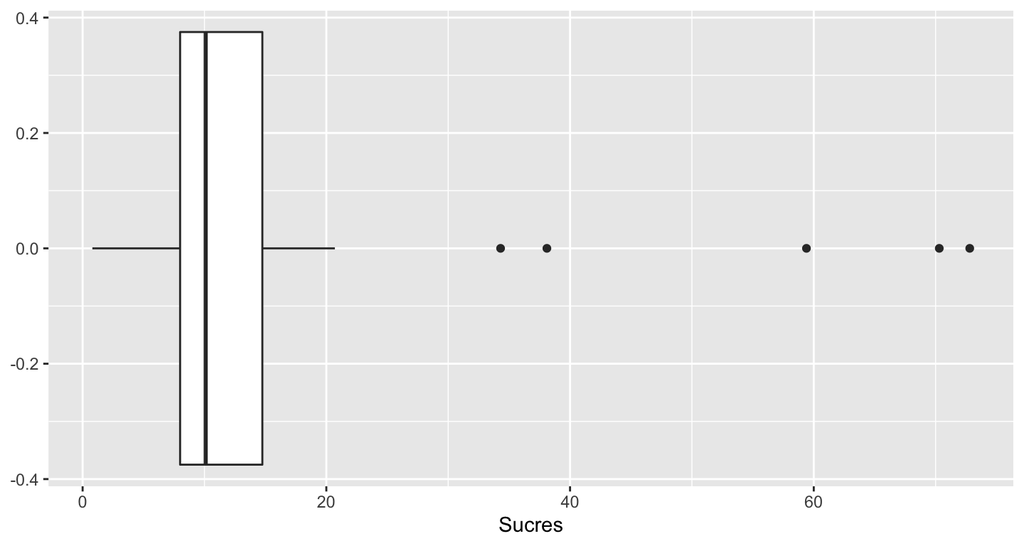

```r
ggplot(data=fruits, aes(x = Sucres)) +
  geom_boxplot()
```

## Boxplot : lien entre une variable catégorielle et une variable continue

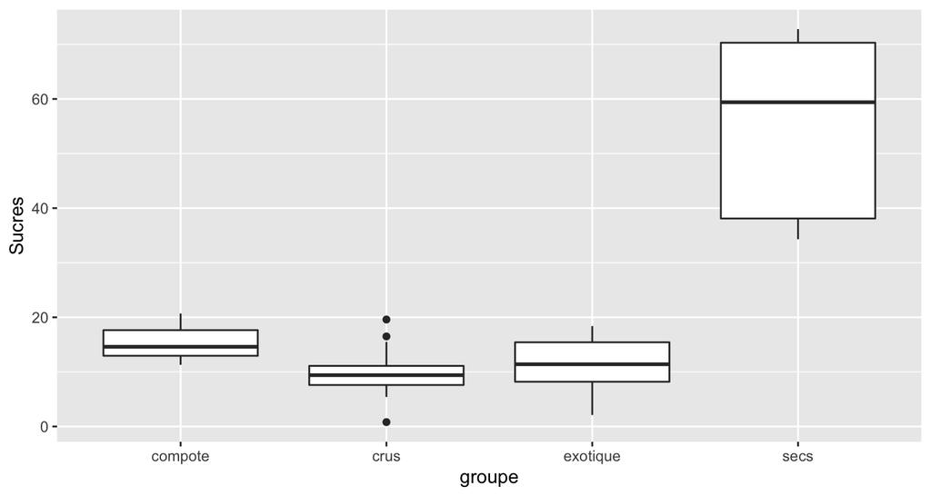

```r
ggplot(data=fruits, aes(x=groupe, y=Sucres)) +
  geom_boxplot()
```

## Avec des violons

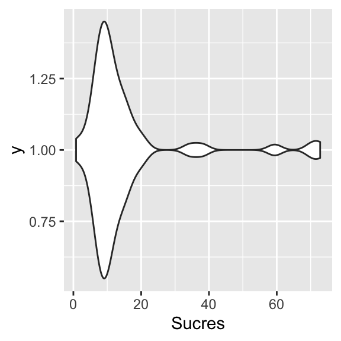

```r
ggplot(data=fruits,
       aes(x = Sucres, y = 1)) +
  geom_violin()
```

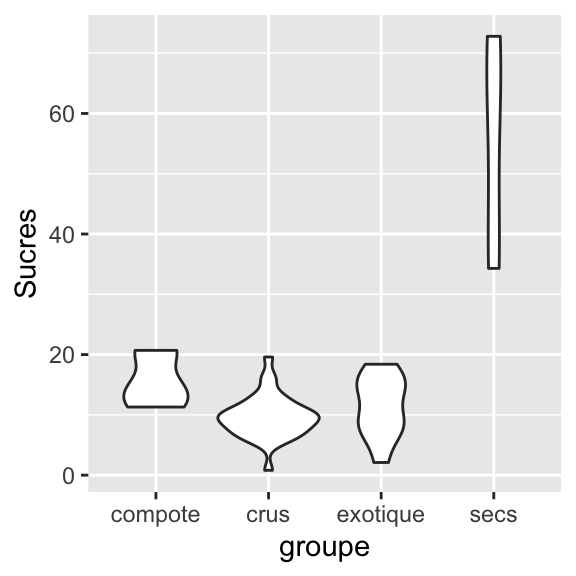

```r
ggplot(data=fruits,
       aes(x = groupe, y = Sucres)) +
  geom_violin()
```

## A vous !

Complétez le code suivant pour obtenir la figure de droite :

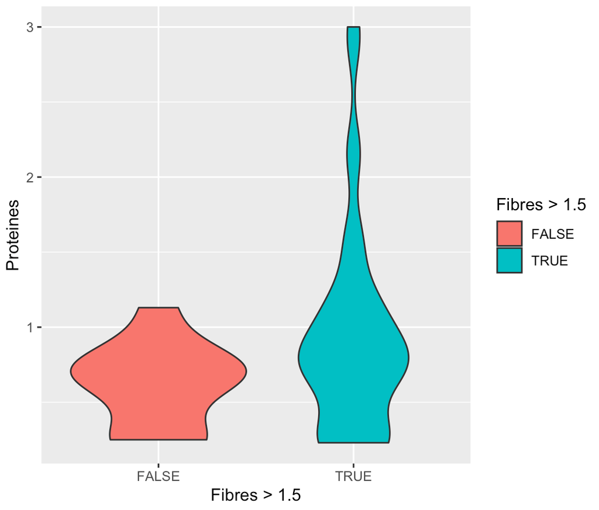

```r
ggplot(fruits,
       aes(x = Fibres > 1.5,
           y = Proteines,
           fill = ***)) +
  geom_***()
```

## Personnalisation

## Thèmes

Les *thèmes* sont des fonctions qui permettent de modifier certains paramètres graphiques comme :

- la couleur du fond,
- la couleur des axes,
- la couleur des grilles majeures et mineures,
- etc.

Exemple de fonctions thèmes (`theme_***()`) :

- `theme_bw()` : pour un thème en noir et blanc,
- `theme_minimal()` : pour un thème minimaliste,
- `theme_void()` : pour un thème dépouillé

## Exemple sur un histogramme : `theme_bw()`

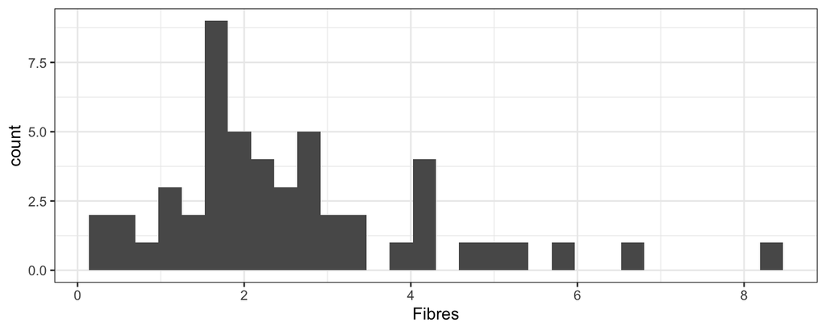

```r
ggplot(fruits, aes(Fibres)) +
  geom_histogram() +
  theme_bw()
```

## Exemple sur un histogramme : `theme_minimal()`

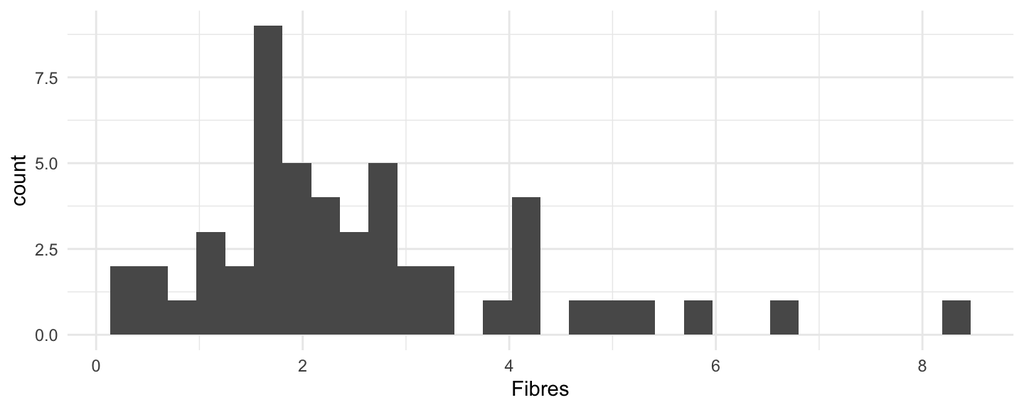

```r
ggplot(fruits, aes(Fibres)) +
  geom_histogram() +
  theme_minimal()
```

## Exemple sur un histogramme : `theme_void()`

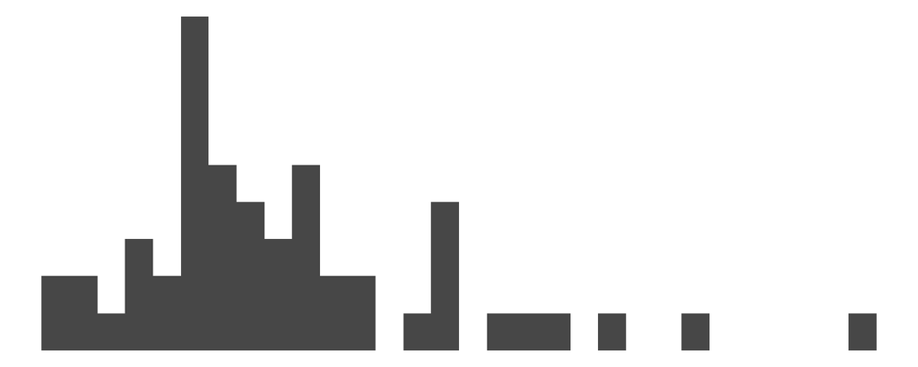

```r
ggplot(fruits, aes(Fibres)) +
  geom_histogram() +
  theme_void()
```

## A vous !

1. Consultez la page d’aide de la fonction `theme_bw` avec la commande `?theme_bw`
2. Choisissez la thème permettant de réaiser le graphe à droite en complétant la commande suivante.

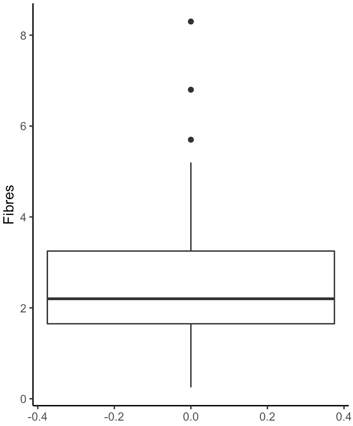

```r
ggplot(fruits, aes(y = Fibres)) +
  geom_boxplot() +
  theme_***()
```

## Autres personnalisations “simples”

- **Titre** : avec la fonction `ggtitle`
- **Titre de l’axe des \(x\)** : avec la fonction `xlab`
- **Titre de l’axe des \(y\)** : avec la fonction `ylab`

Mais je vous conseille d’utiliser la fonction `labs` qui permet de faire tout cela, et plus !

```r
labs(
  title = "Titre du graphe",
  subtitle = "Sous-titre du graphe",
  x = "Titre de l'axe des x",
  y = "Titre de l'axe des y",
  color = "Titre de la légende des couleurs",
  shape = "Titre de la légende des formes"
)
```